# Customer Personality Analysis

### Life cycle of the Project

1. Problem Statement
2. Data Collection
3. Data Cleaning
4. Exploratory data analysis
5. Data Pre-Processing
6. Model Training
7. Choose best model
8. Recommendations

### 1) Problem Statement

- Summarize customer segments by performing clustering

### 2) Data Collection

- Data source: https://www.kaggle.com/datasets/imakash3011/customer-personality-analysis
- Data consists of 29 attributes -including the ID column- and 2240 samples.

```python
import pandas as pd
pd.set_option('display.max_colwidth', None)
import numpy as np
import seaborn as sns
import matplotlib.pyplot as plt
import math
%matplotlib inline
import warnings
warnings.filterwarnings('ignore')
```

```python
#dataset_path = '/content/drive/MyDrive/DS_Project/marketing_campaign.csv'
dataset = pd.read_csv('marketing_campaign.csv', index_col= 'ID')
dataset = dataset.drop(['Z_Revenue', 'Z_CostContact'], axis = 1) #redundent features + no given information
dataset.head(10)
```

| ID | Year_Birth | Education | Marital_Status | Income | Kidhome | Teenhome | Dt_Customer | Recency | Complain | MntDrinks | ... | AcceptedCmp1 | AcceptedCmp2 | AcceptedCmp3 | AcceptedCmp4 | AcceptedCmp5 | Response | NumWebPurchases | NumCatalogPurchases | NumStorePurchases | NumWebVisitsMonth |
| --- | --- | --- | --- | --- | --- | --- | --- | --- | --- | --- | --- | --- | --- | --- | --- | --- | --- | --- | --- | --- | --- |
| 0 | 1985 | Graduation | Married | 70951.0 | 0 | 0 | 04-05-2013 | 66 | 0 | 239 | ... | 0 | 0 | 0 | 0 | 0 | 0 | 3 | 4 | 9 | 1 |
| 1 | 1961 | Graduation | Single | 57091.0 | 0 | 0 | 15-06-2014 | 0 | 0 | 464 | ... | 0 | 1 | 0 | 0 | 0 | 1 | 7 | 3 | 7 | 5 |
| 9 | 1975 | Master | Single | 46098.0 | 1 | 1 | 18-08-2012 | 86 | 0 | 57 | ... | 0 | 0 | 0 | 0 | 0 | 0 | 3 | 2 | 2 | 8 |
| 13 | 1947 | PhD | Widow | 25358.0 | 0 | 1 | 22-07-2013 | 57 | 0 | 19 | ... | 0 | 0 | 0 | 0 | 0 | 0 | 1 | 0 | 3 | 6 |
| 17 | 1971 | PhD | Married | 60491.0 | 0 | 1 | 06-09-2013 | 81 | 0 | 637 | ... | 0 | 0 | 0 | 0 | 0 | 0 | 6 | 11 | 7 | 5 |
| 20 | 1965 | 2n Cycle | Married | 46891.0 | 0 | 1 | 01-09-2013 | 91 | 0 | 43 | ... | 0 | 0 | 0 | 0 | 0 | 0 | 2 | 1 | 4 | 4 |
| 22 | 1976 | Graduation | Divorced | 46310.0 | 1 | 0 | 03-12-2012 | 99 | 0 | 185 | ... | 0 | 0 | 0 | 0 | 0 | 0 | 6 | 1 | 5 | 8 |
| 24 | 1960 | Master | Together | 17144.0 | 1 | 1 | 15-02-2014 | 96 | 0 | 18 | ... | 0 | 0 | 0 | 0 | 0 | 0 | 3 | 0 | 4 | 7 |
| 25 | 1958 | Graduation | Married | 65148.0 | 0 | 1 | 16-11-2012 | 9 | 0 | 460 | ... | 0 | 0 | 0 | 0 | 0 | 0 | 6 | 6 | 7 | 4 |
| 35 | 1987 | Graduation | Married | 25545.0 | 1 | 0 | 08-09-2012 | 35 | 0 | 32 | ... | 0 | 0 | 0 | 0 | 0 | 1 | 2 | 2 | 3 | 6 |

10 rows × 26 columns

```python
raw_description = ['Customer birth year', 'Customer education level', 'Customer marital status', 'Customer yearly household income',\
                       'Number of children in customer household', 'Number of teenagers in customer household', 'Date of customer enrollment with the company',\
                       'Number of days since customer last purchase', '1 if the customer complained in the last 2 years, 0 otherwise', 'Amount spent on drink in last 2 years',\
                       'Amount spent on fruits in last 2 years', 'Amount spent on meat in last 2 years', 'Amount spent on fish in last 2 years', 'Amount spent on sweets in last 2 years',\
                       'Amount spent on gold in last 2 years', 'Number of purchases made with a discount', '1 if customer accepted the offer in the 1st campaign, 0 otherwise',\
                       '1 if customer accepted the offer in the 2nd campaign, 0 otherwise', '1 if customer accepted the offer in the 3rd campaign, 0 otherwise', '1 if customer accepted the offer in the 4th campaign, 0 otherwise',\
                       '1 if customer accepted the offer in the 5th campaign, 0 otherwise', '1 if customer accepted the offer in the last campaign, 0 otherwise', 'Number of purchases made through the company website',\
                       'Number of purchases made using a catalogue', 'Number of purchases made directly in stores', 'Number of visits to company website in the last month' ]

raw_description

dataset_description = list(zip(dataset.columns, raw_description))
cols = ['Attribute', 'Description']
table = pd.DataFrame(dataset_description, index = [i for i in range(1,len(dataset_description)+1)], columns= cols)
table
```

|  | Attribute | Description |
| --- | --- | --- |
| 1 | Year_Birth | Customer birth year |
| 2 | Education | Customer education level |
| 3 | Marital_Status | Customer marital status |
| 4 | Income | Customer yearly household income |
| 5 | Kidhome | Number of children in customer household |
| 6 | Teenhome | Number of teenagers in customer household |
| 7 | Dt_Customer | Date of customer enrollment with the company |
| 8 | Recency | Number of days since customer last purchase |
| 9 | Complain | 1 if the customer complained in the last 2 years, 0 otherwise |
| 10 | MntDrinks | Amount spent on drink in last 2 years |
| 11 | MntFruits | Amount spent on fruits in last 2 years |
| 12 | MntMeatProducts | Amount spent on meat in last 2 years |
| 13 | MntFishProducts | Amount spent on fish in last 2 years |
| 14 | MntSweetProducts | Amount spent on sweets in last 2 years |
| 15 | MntGoldProds | Amount spent on gold in last 2 years |
| 16 | NumDealsPurchases | Number of purchases made with a discount |
| 17 | AcceptedCmp1 | 1 if customer accepted the offer in the 1st campaign, 0 otherwise |
| 18 | AcceptedCmp2 | 1 if customer accepted the offer in the 2nd campaign, 0 otherwise |
| 19 | AcceptedCmp3 | 1 if customer accepted the offer in the 3rd campaign, 0 otherwise |
| 20 | AcceptedCmp4 | 1 if customer accepted the offer in the 4th campaign, 0 otherwise |
| 21 | AcceptedCmp5 | 1 if customer accepted the offer in the 5th campaign, 0 otherwise |
| 22 | Response | 1 if customer accepted the offer in the last campaign, 0 otherwise |
| 23 | NumWebPurchases | Number of purchases made through the company website |
| 24 | NumCatalogPurchases | Number of purchases made using a catalogue |
| 25 | NumStorePurchases | Number of purchases made directly in stores |
| 26 | NumWebVisitsMonth | Number of visits to company website in the last month |

```python
print(f'shape of raw dataset {dataset.shape}')
```

```
shape of raw dataset (2240, 26)
```

### 3. Data Cleaning

```
<class 'pandas.core.frame.DataFrame'>
Int64Index: 2240 entries, 0 to 11191
Data columns (total 26 columns):
 #   Column               Non-Null Count  Dtype
---  ------               --------------  -----
 0   Year_Birth           2240 non-null   int64
 1   Education            2240 non-null   object
 2   Marital_Status       2240 non-null   object
 3   Income               2216 non-null   float64
 4   Kidhome              2240 non-null   int64
 5   Teenhome             2240 non-null   int64
 6   Dt_Customer          2240 non-null   object
 7   Recency              2240 non-null   int64
 8   Complain             2240 non-null   int64
 9   MntDrinks            2240 non-null   int64
```

[output cut: 18 more lines]

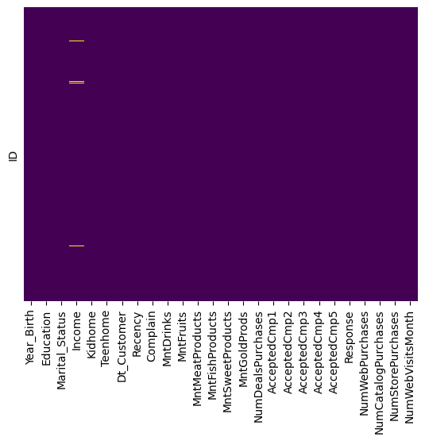

```python
dataset.info()
display(sns.heatmap(dataset.isnull(), cmap = 'viridis', yticklabels=False, cbar=False))
```

**Observations:**

1. Income attribute has missing value. (Type of missing data: Missing At Random)

   > Will be handeled using Multivariate imputer. We will use the numerical features to impute the null values in the income feature. (Supervised learning technique). Why? because the missing values of the feature are of type (missing at random) and has outliers.
2. Three categorical attributes (object) needs numeric encoding.

> Will be handeled using hot-encoding

**Table showing imputation methods for the types of missing data:**

[figure not shown]

```python
from sklearn.experimental import enable_iterative_imputer
from sklearn.impute import IterativeImputer
from sklearn.ensemble import GradientBoostingRegressor
```

Iterative imputation using gradient boosting regressor

```python
dataset_to_impute = dataset[[col for col in dataset.columns if dataset[col].dtype != object]]
dataset_to_impute.drop(columns='Year_Birth', inplace= True)
```

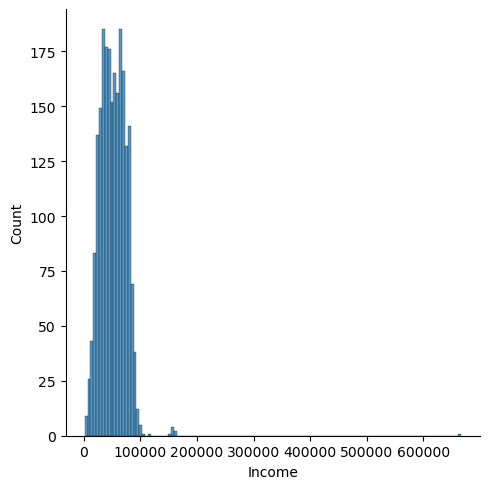

```python
sns.displot(dataset['Income'])
```

- Because the income feature has outliers, we need an algorithm that does not get affected by outliers. Mainly tree algorithms.
- In this case, we will use Gradient boosing regressor as our model. GBR has Decision Trees as the fixed base estimator.

```python
imp = IterativeImputer(estimator = GradientBoostingRegressor())

imputed_data = imp.fit_transform(dataset_to_impute)

imputed_data = pd.DataFrame(imputed_data, columns = dataset_to_impute.columns)

print('The null values count of the Income feature after imputation is: ', imputed_data['Income'].isnull().sum())
```

```
The null values count of the Income feature after imputation is:  0
```

Mean and Median Imputation

```python
mean_value = dataset_to_impute.mean()
mean_imputation = dataset_to_impute.fillna(mean_value)
median_value = dataset_to_impute.median()
median_imputation = dataset_to_impute.fillna(median_value)
```

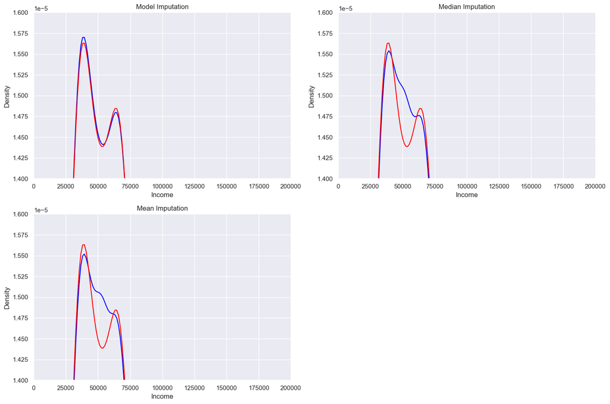

```python
# Create 2x2 sub plots
import matplotlib.gridspec as gridspec
gs = gridspec.GridSpec(2, 2)

plt.figure(figsize=(15,10))
ax = plt.subplot(gs[0, 0]) # row 0, col 0
plt.title('Model Imputation')
plt.xlabel('Income')
imputed_data['Income'].plot(kind = 'kde', color = 'blue')
dataset['Income'].plot(kind='kde', color = 'red', xlim=(0,0.2e6), ylim=(1.40e-5,1.6e-5))

ax = plt.subplot(gs[0, 1]) # row 0, col 1
plt.title('Median Imputation')
plt.xlabel('Income')
median_imputation['Income'].plot(kind='kde', color = 'blue')
dataset['Income'].plot(kind='kde', color = 'red', xlim=(0,0.2e6), ylim=(1.40e-5,1.6e-5))

ax = plt.subplot(gs[1, 0]) # row 1, col 0
plt.title('Mean Imputation')
plt.xlabel('Income')
mean_imputation['Income'].plot(kind='kde', color = 'blue')
dataset['Income'].plot(kind='kde', color = 'red', xlim=(0,0.2e6), ylim=(1.40e-5,1.6e-5))


plt.tight_layout()
```

**Observations**:

1. It is clear that the Iterative imputation yield the closest distribution of the original data. Therefore, we will consider the Iterative imputation to fill the null values of the income feature.

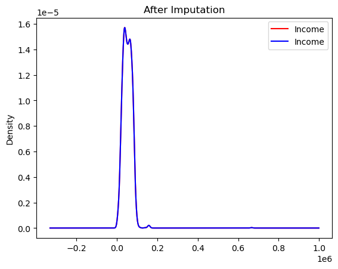

```python
clean_dataset = dataset.copy()

plt.title('After Imputation')
clean_dataset['Income'] = imputed_data['Income'].values
clean_dataset['Income'].plot(kind='kde', color = 'red')
imputed_data['Income'].plot(kind = 'kde', color='blue')
plt.legend(loc="upper right")
```

```python
clean_dataset['Income'].isnull().sum()
```

```
0
```

**Observations**:

1. Iterative imputated data has been added to the original dataset.

> This concludes the missing value imputation phase.

Handeling Duplicated Samples

```python
clean_dataset.duplicated().sum()
```

```
182
```

**Observations**:

1. Number of duplicated samples are = 182

> Will be handeled by dropping duplicates

```python
clean_dataset.drop_duplicates(keep='first', inplace=True)
clean_dataset.shape

print(f'Shape of dataset after dropping duplicates: {clean_dataset.shape}')
```

```
Shape of dataset after dropping duplicates: (2058, 26)
```

Handeling Categorical Features

```python
print('Categories of the feature: Education \n')
print(clean_dataset['Education'].unique(), '\n')

print('Categories of the feature: Marital Status \n')
print(clean_dataset['Marital_Status'].unique(), '\n')
```

```
Categories of the feature: Education

['Graduation' 'Master' 'PhD' '2n Cycle' 'Basic']

Categories of the feature: Marital Status

['Married' 'Single' 'Widow' 'Divorced' 'Together' 'Alone' 'YOLO' 'Absurd']
```

**Observations**:

   > We will encode the cateogires into two main classes: Together and Alone.

```python
encoded_education = {
      'Master':      'Postgraduate',
      'PhD':         'Postgraduate',
      'Graduation':  'Graduate',
      '2n Cycle':    'Postgraduate',
      'Basic':       'Undergraduate'
}

encoded_status = {
    'Married':  'Together',
    'Single':   'Alone',
    'Widow':    'Alone',
    'Divorced': 'Alone',
    'Together': 'Together',
    'Alone':    'Alone',
    'YOLO':     'Alone',
    'Absurd':   'Alone'
    }
```

```python
clean_dataset['Education'] = clean_dataset['Education'].apply(lambda x: encoded_education[x])
clean_dataset['Marital_Status'] = clean_dataset['Marital_Status'].apply(lambda x: encoded_status[x])
```

```python
print('Categories of the feature Education after encoding \n')
print(clean_dataset['Education'].unique(), '\n')

print('Categories of the feature Marital Status after encoding \n')
print(clean_dataset['Marital_Status'].unique(), '\n')
```

```
Categories of the feature Education after encoding

['Graduate' 'Postgraduate' 'Undergraduate']

Categories of the feature Marital Status after encoding

['Together' 'Alone']
```

#### Feature Engineering

```python
clean_dataset['Dt_Customer']
clean_dataset["Dt_Customer"] = pd.to_datetime(clean_dataset["Dt_Customer"])
```

**Observations**:

1. We will extract one feature from the attribute ['Dt Customer']

   > The feature will contain the number of days since the join of each customer from today. Feature will be called [' DaysJoin '], Days since 2015.

(why 2015?)\ *Becuase the dataset is quite old. We will do our analysis from this point going forward till the latest year in the dataset, 2015. This includes the age of the customers. (will be discussed later on)*

```python
dates = []
for date in clean_dataset['Dt_Customer']:
    dates.append(date.date())

print('most recent join was at: ', max(dates))
```

```
most recent join was at:  2014-12-06
```

```python
daysjoin = []
for date in dates:
    daysjoin.append(max(dates) - date)

clean_dataset['DaysJoin'] = daysjoin
clean_dataset['DaysJoin'] = pd.to_numeric(clean_dataset['DaysJoin'].dt.days, downcast='integer')
clean_dataset.drop(columns=['Dt_Customer'], inplace= True)
```

```python
display(clean_dataset[['MntDrinks',
       'MntFruits', 'MntMeatProducts', 'MntFishProducts', 'MntSweetProducts',
       'MntGoldProds', 'NumDealsPurchases']].head(5),
       clean_dataset[['Kidhome', 'Teenhome']].head(5),
       clean_dataset[['Year_Birth']].head(5)
       )
```

| ID | MntDrinks | MntFruits | MntMeatProducts | MntFishProducts | MntSweetProducts | MntGoldProds | NumDealsPurchases |
| --- | --- | --- | --- | --- | --- | --- | --- |
| 0 | 239 | 10 | 554 | 254 | 87 | 54 | 1 |
| 1 | 464 | 5 | 64 | 7 | 0 | 37 | 1 |
| 9 | 57 | 0 | 27 | 0 | 0 | 36 | 4 |
| 13 | 19 | 0 | 5 | 0 | 0 | 8 | 2 |
| 17 | 637 | 47 | 237 | 12 | 19 | 76 | 4 |

| ID | Kidhome | Teenhome |
| --- | --- | --- |
| 0 | 0 | 0 |
| 1 | 0 | 0 |
| 9 | 1 | 1 |
| 13 | 0 | 1 |
| 17 | 0 | 1 |

| ID | Year_Birth |
| --- | --- |
| 0 | 1985 |
| 1 | 1961 |
| 9 | 1975 |
| 13 | 1947 |
| 17 | 1971 |

**Observations**:

1. The first table depicts the amount spent in various products.

   > We will engineer these features into 1 feature called TotalSpent
2. The second table depicts the number of kids and teens each customer have.

   > We will engineer these features into 1 feature called childern
3. The third table depicts the year of birth of each customer.

   > It is best to have this feature as the Age feature of each customer. Because the dataset is old (max year is 2015), we will only consider the age until 2015. Considering the age from today will lead to baised analysis because affliated information on these years is not available.

```python
clean_dataset['TotalSpent'] = clean_dataset['MntDrinks']+ clean_dataset['MntFruits']+ clean_dataset['MntMeatProducts']+ clean_dataset['MntFishProducts']\
                          + clean_dataset['MntSweetProducts'] + clean_dataset['NumDealsPurchases']+clean_dataset['MntGoldProds']

clean_dataset['Children'] = clean_dataset['Kidhome'] + clean_dataset['Teenhome']

clean_dataset['Age'] = 2015 - clean_dataset['Year_Birth']  #As discussed earlier
```

We will Also add four features

1. TotalMembers: number of members
2. TotalPurchase: Number of purchases
3. Parent: if the customer is a parent
4. TotalAcceptedCamps: number of accepted camps per customer.

This will help us greatly in clustering because these features affect the shopping behavior.

```python
clean_dataset['TotalMembers'] = clean_dataset['Children'] + clean_dataset['Marital_Status'].replace({'Together': 2, 'Alone': 1})
clean_dataset['Parent'] = np.where(clean_dataset['TotalMembers'] > 2, 1, 0) #For visualization
clean_dataset['TotalPurchase'] = clean_dataset['NumWebPurchases'] + clean_dataset['NumCatalogPurchases'] + clean_dataset['NumStorePurchases'] + clean_dataset['NumDealsPurchases']
clean_dataset['TotalAcceptedCamps'] = clean_dataset['AcceptedCmp1'] + clean_dataset['AcceptedCmp2'] + clean_dataset['AcceptedCmp3']+ clean_dataset['AcceptedCmp4'] + clean_dataset['AcceptedCmp5']
```

Lastly we will check if there are any outliers in the dataset

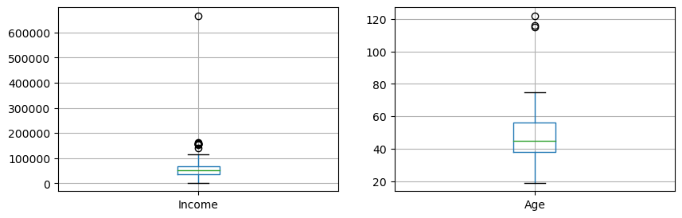

```python
fig, ax = plt.subplots(1,2, figsize=(10,3))
clean_dataset.boxplot(column=['Income'], ax=ax[0])
clean_dataset.boxplot(column=['Age'], ax=ax[1])
```

**Observations**:

> outliers will be treated with a filter

Applying Filter for the features

```python
clean_dataset = clean_dataset[clean_dataset['Age']<100]
clean_dataset = clean_dataset[clean_dataset['Income']<200000]
```

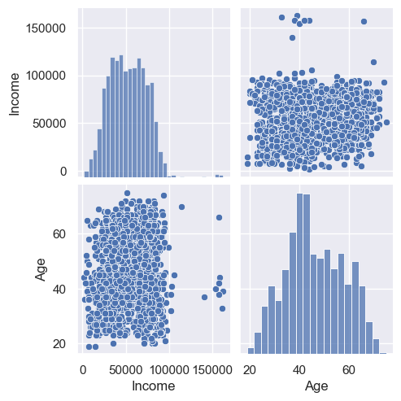

```python
#After applying a filter
features = ['Income', 'Age']
sns.pairplot(clean_dataset[features])
```

**This concludes the Data Cleaning Stage**

## 4) Exploratory Data Analysis

The goal is to find some characteristics of customers who spend the most.

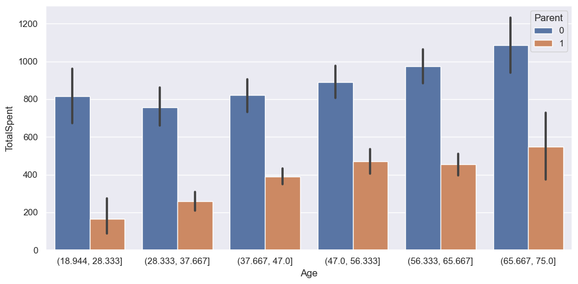

```python
sns.set_theme()
plt.figure(figsize=(10,5))
sns.barplot(data = clean_dataset, x = pd.cut(clean_dataset['Age'], bins=6), y = 'TotalSpent', hue = 'Parent')
plt.tight_layout()
plt.show()
```

- We can see that as age increases, the spending also increase, except for the first age group (19 to 27).
- It looks like customers who are not parents spend more. we need to investigate the type of items these age groups buy.

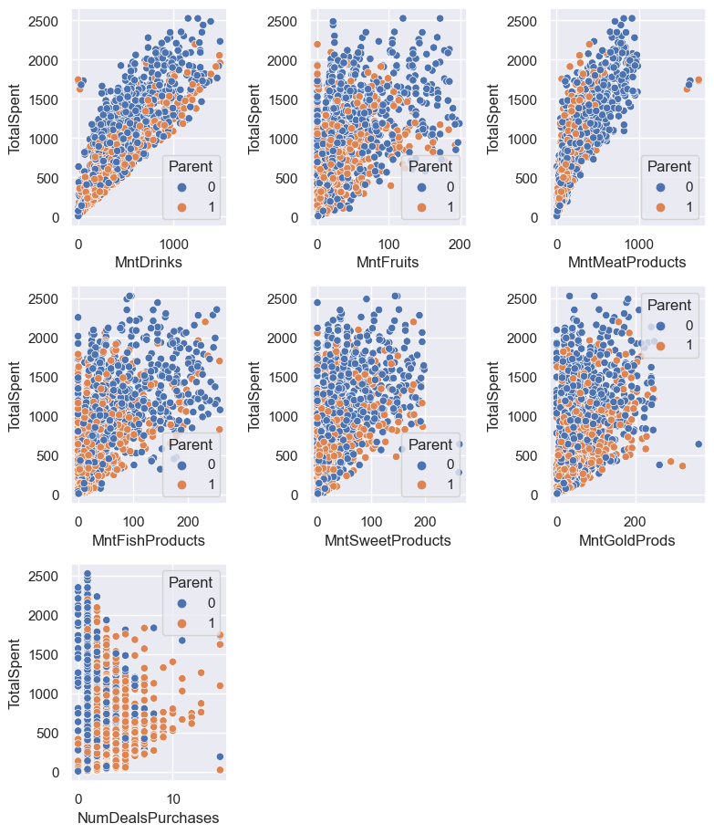

```python
#plots for products versus total spendings
features_df = clean_dataset[['MntDrinks', 'MntFruits',
       'MntMeatProducts', 'MntFishProducts', 'MntSweetProducts',
       'MntGoldProds', 'NumDealsPurchases']]

plt.figure(figsize=(8,3*features_df.shape[1]))

i=1
nrows = int(features_df.shape[1]+1/3)
for feature in features_df.columns:
       plt.subplot(nrows, 3, i)
       # Plot the feature
       sns.scatterplot(data = features_df, x = feature, y = clean_dataset['TotalSpent'], hue =clean_dataset['Parent'])
       color=np.random.rand(3,)
       i+=1

plt.tight_layout()
plt.show()
```

- Customers who are not a parent precede parents in purchasing fruits, fish, and meat products.
- Both groups spend relatively the same amount on drinks.
- Parents take good advantage of deals and spend more on deals.

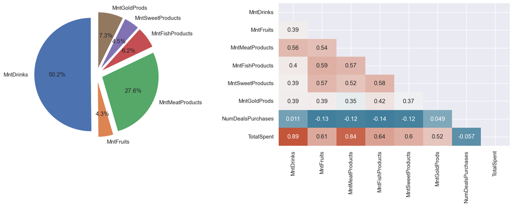

```python
gs = gridspec.GridSpec(2, 2)

plt.figure(figsize=(15,10))
ax = plt.subplot(gs[0, 0]) # row 0, col 0
#pie plot
counts = []
features = ['MntDrinks','MntFruits', 'MntMeatProducts', 'MntFishProducts', 'MntSweetProducts','MntGoldProds']
for feature in features:
    counts.append(dataset[feature].sum())
plt.pie(counts, labels = features, startangle = 90, autopct='%1.1f%%', explode=(0.1,0.1,0.1,0.1,0.1,0.1))

ax = plt.subplot(gs[0, 1]) # row 0, col 0
#correlation matrix for products
dataset['TotalSpent'] = clean_dataset['TotalSpent']
product_corr = dataset[['MntDrinks', 'MntFruits',
       'MntMeatProducts', 'MntFishProducts', 'MntSweetProducts',
       'MntGoldProds', 'NumDealsPurchases', 'TotalSpent']].corr(method = 'pearson')

mask = np.triu(np.ones_like(product_corr, dtype=bool))
cmap = sns.diverging_palette(230, 20, as_cmap=True)
sns.heatmap(product_corr, annot=True, mask = mask, cmap=cmap, cbar=False)

plt.tight_layout()
```

- The most purchased item is: drinks, followed by the meat products.
- Customers spend most on drinks and meat products. (both features have a correlation greater than 80% with Total spendings)

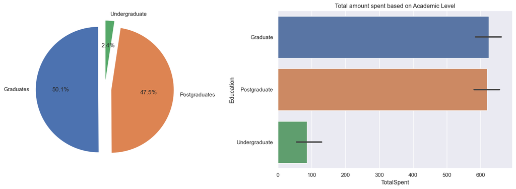

```python
gs = gridspec.GridSpec(2, 2)

plt.figure(figsize=(15,10))
ax = plt.subplot(gs[0, 0]) # row 0, col 0
y = np.array([clean_dataset['Education'].value_counts()[0], clean_dataset['Education'].value_counts()[1],clean_dataset['Education'].value_counts()[2]])
mylabels = ["Graduates","Postgraduates", "Undergraduate"]
plt.pie(y, labels = mylabels, startangle = 90, autopct='%1.1f%%', explode=(0.1, 0.1, 0.1))

ax = plt.subplot(gs[0, 1]) # row 0, col 1
plt.title('Total amount spent based on Academic Level')
sns.barplot(data = clean_dataset, x = 'TotalSpent', y = 'Education')

plt.tight_layout()
```

- The majority of customers are graduates and postgraduate (roughly 98%) and they spend more than undergraduate.

```
Mean: $ 52,047.26
```

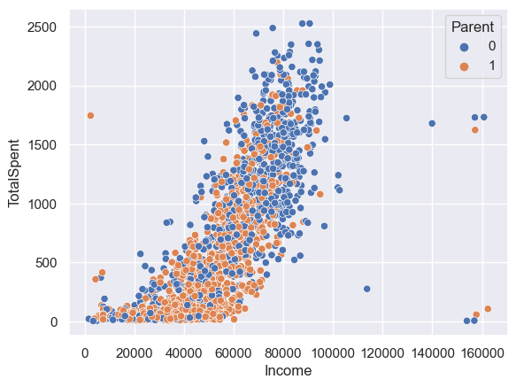

```python
sns.scatterplot(data=clean_dataset, x='Income', y = 'TotalSpent', hue = clean_dataset['Parent'])
mean = round(clean_dataset['Income'].mean(),2)
print(f'Mean: $ {mean:,}')
```

1. Spending increase with income level.
2. The annual mean income of customers is $52k.
3. Customers who are not a parent spend the most

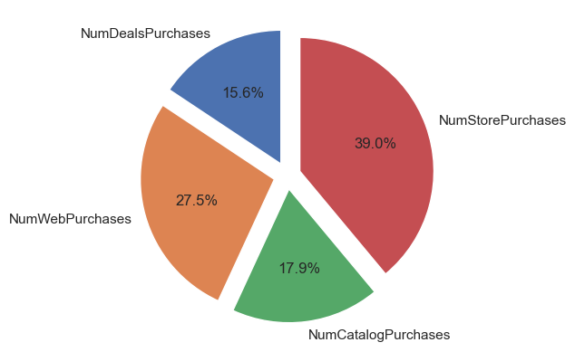

```python
counts = []
features = ['NumDealsPurchases','NumWebPurchases', 'NumCatalogPurchases', 'NumStorePurchases']
for feature in features:
    counts.append(dataset[feature].sum())
plt.pie(counts, labels = features, startangle = 90, autopct='%1.1f%%', explode=(0.1,0.1,0.1,0.1))
plt.show()
```

Customers perfer purchasing directly from the store and from the website

```
                   NumWebVisitsMonth  NumWebPurchases
NumWebVisitsMonth           1.000000        -0.055846
NumWebPurchases            -0.055846         1.000000
```

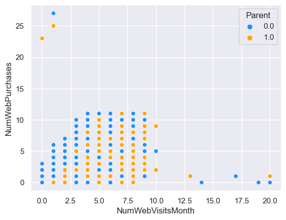

```python
sns.scatterplot(x = dataset['NumWebVisitsMonth'], y = dataset['NumWebPurchases'], hue = clean_dataset['Parent'], palette=['dodgerblue','orange'])
dataset[['NumWebVisitsMonth','NumWebPurchases']].corr(method = 'pearson')

print(dataset[['NumWebVisitsMonth','NumWebPurchases']].corr())
```

- Both groups record the same amount of visits last month on the website.
- Customers who buy from the website are not frequent customers. They might buy for 2-3 months forward.
- Customers who buy little from the website tend to be frequent monthly active customers.
- We have spectator customers who just surf the website and never buys...
- We can see that there is a negative correlation (-0.056) between number of website visits last month and the number of web purchases. The company needs investigate what happend last month and bringforth some innovative solutions regarding their online marketing strategy.

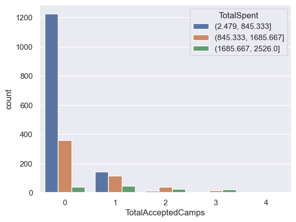

```python
sns.countplot(x='TotalAcceptedCamps', data=clean_dataset, hue=pd.cut(clean_dataset['TotalSpent'], bins=3))
plt.show()
```

**Conclusion**:

**This concludes exploratory data analysis**

## 5) Data Preproceesing

- We will drop features that were used to generate new, meaningful features.
- We will drop features that do not include 2 years information (NumWebVisitsMonth).
- Label encode categorical variables, and scale it using standardization.
- We will drop very low variance features if they do not contribute much to the variation of data.

```python
old_features = [
                'Year_Birth', #generated: Age
                'Kidhome','Teenhome', #generated: Children
                'MntDrinks', 'MntFruits','MntMeatProducts', 'MntFishProducts', 'MntSweetProducts', 'MntGoldProds', #generated: TotalSpent
                'NumDealsPurchases','NumWebPurchases', 'NumCatalogPurchases', 'NumStorePurchases', #generated: TotalPurchase
                'AcceptedCmp1', 'AcceptedCmp2','AcceptedCmp3', 'AcceptedCmp4', 'AcceptedCmp5', #generated: TotalAcceptedCamps
                'Response', 'NumWebVisitsMonth', 'Complain' #Response might be used for prediction not clustering, others have information for 1 month only.
                ]
```

```python
pre_dataset = clean_dataset.copy()
pre_dataset.drop(old_features, axis = 1, inplace=True)
```

```python
from sklearn.preprocessing import LabelEncoder
encoder = LabelEncoder()
```

```python
categorical_features = [col for col in pre_dataset.columns if pre_dataset[col].dtype == object]
print('Categorical Features that need encoding: ', categorical_features)

print('\nAfter encoding: ')

encoded_dataset = pre_dataset[['Education', 'Marital_Status']].apply(encoder.fit_transform)
display(encoded_dataset['Education'].value_counts() ,encoded_dataset['Marital_Status'].value_counts())
```

```
Categorical Features that need encoding:  ['Education', 'Marital_Status']

After encoding:
```

```
0    1029
1     976
2      49
Name: Education, dtype: int64
```

```
1    1314
0     740
Name: Marital_Status, dtype: int64
```

```python
pre_dataset['Education'] = encoded_dataset['Education']
pre_dataset['Marital_Status'] = encoded_dataset['Marital_Status']
```

```python
import statistics
variance = {}
for feature in pre_dataset.columns:
       v = (statistics.variance(pre_dataset[feature]))
       variance[feature] = v

low_variance_features = []

for  key ,value in variance.items():
    if value <= 0.6:
        low_variance_features.append(key)

print('Features that have low variance: ',low_variance_features)
```

```
Features that have low variance:  ['Education', 'Marital_Status', 'Children', 'Parent', 'TotalAcceptedCamps']
```

```python
import statistics
variance = {}
for feature in pre_dataset.columns:
       v = (statistics.variance(pre_dataset[feature]))
       variance[feature] = v

low_variance_features = []

for  key ,value in variance.items():
    if value <= 0.6:
        low_variance_features.append(key)

print('Features that have low variance: ',low_variance_features)
```

```
Features that have low variance:  ['Education', 'Marital_Status', 'Children', 'Parent', 'TotalAcceptedCamps']
```

```python
pre_dataset.drop(['Education', 'Marital_Status', 'Children', 'Parent', 'TotalAcceptedCamps'], axis = 1, inplace=True)
```

```python
from sklearn.preprocessing import StandardScaler
scaler = StandardScaler()
scaler.fit(pre_dataset)
scaled_features = (scaler.transform(pre_dataset.values))
scaled_dataset = pd.DataFrame(scaled_features, columns=pre_dataset.columns)
```

```python
scaled_dataset
```

|  | Income | Recency | DaysJoin | TotalSpent | Age | TotalMembers | TotalPurchase |
| --- | --- | --- | --- | --- | --- | --- | --- |
| 0 | 0.874434 | 0.587888 | 0.424373 | 0.980160 | -1.381279 | -0.656081 | 0.276586 |
| 1 | 0.233309 | -1.689024 | -1.450503 | -0.051127 | 0.676178 | -1.758857 | 0.407095 |
| 2 | -0.275196 | 1.277862 | 1.413414 | -0.805079 | -0.524005 | 0.446694 | -0.506470 |
| 3 | -1.234571 | 0.277400 | -0.040046 | -0.954541 | 1.876360 | -0.656081 | -1.159016 |
| 4 | 0.390584 | 1.105368 | 0.144862 | 0.702825 | -0.181096 | 0.446694 | 1.712188 |
| ... | ... | ... | ... | ... | ... | ... | ... |
| 2049 | 0.643935 | -1.275040 | -2.194434 | -0.185643 | -0.095369 | 0.446694 | 0.407095 |
| 2050 | -0.446533 | 0.691384 | -1.089289 | -0.956202 | -0.266823 | -0.656081 | -1.289526 |
| 2051 | 4.851307 | 1.243363 | -0.203452 | -0.997719 | 1.704906 | -0.656081 | -1.942072 |
| 2052 | -1.182347 | -0.895555 | 0.230865 | -0.891435 | -0.781187 | -0.656081 | -0.767489 |
| 2053 | -0.492004 | -1.309539 | 0.002956 | -0.778508 | -1.467006 | -1.758857 | -0.897998 |

2054 rows × 7 columns

#### This concludes data preprocessing

## 6) Model fitting

```python
from sklearn.cluster import KMeans, MiniBatchKMeans
```

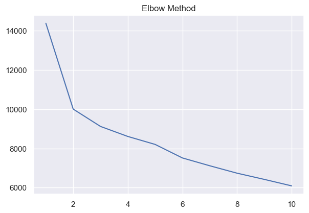

```python
gs = gridspec.GridSpec(2, 2)

plt.figure(figsize=(15,10))
ax = plt.subplot(gs[0, 0]) # row 0, col 0
wcss = []
for i in range(1, 11):
    model = MiniBatchKMeans(n_clusters=i, init='k-means++')
    model.fit_predict(scaled_dataset)
    wcss.append(model.inertia_)
plt.title('Elbow Method')
plt.plot(range(1,11), wcss)
```

```python
cluster_dataset = clean_dataset.copy()
```

## KMeans

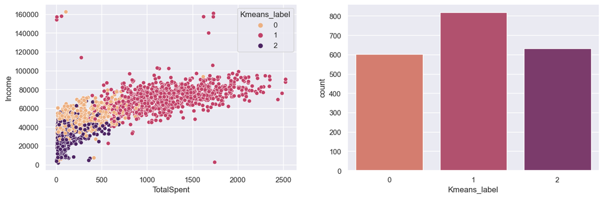

```python
model = KMeans(3)
final_model = model.fit_predict(scaled_dataset)
cluster_dataset['Kmeans_label'] = final_model

plt.figure(figsize=(15,10))
ax = plt.subplot(gs[0, 0]) # row 0, col 0
sns.scatterplot(data=cluster_dataset, x = 'TotalSpent', y='Income', hue = 'Kmeans_label', palette='flare')
ax = plt.subplot(gs[0, 1]) # row 0, col 0
sns.countplot(x = cluster_dataset['Kmeans_label'], palette='flare')
```

## KMediods

```python
from sklearn_extra.cluster import KMedoids
```

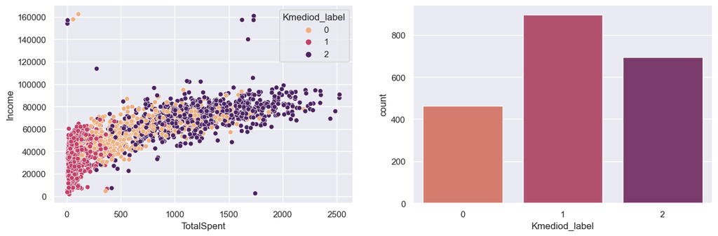

```python
model = KMedoids(3)
final_model = model.fit_predict(scaled_dataset)
cluster_dataset['Kmediod_label'] = final_model
#plot
plt.figure(figsize=(15,10))
ax = plt.subplot(gs[0, 0]) # row 0, col 0
sns.scatterplot(data=cluster_dataset, x = 'TotalSpent', y='Income', hue = 'Kmediod_label', palette='flare')
ax = plt.subplot(gs[0, 1]) # row 0, col 0
sns.countplot(x = cluster_dataset['Kmediod_label'], palette='flare')
```

## GaussianMixture

```python
from sklearn.mixture import GaussianMixture
from sklearn.preprocessing import normalize
```

```python
scaled_dataset2 = normalize(scaled_dataset,norm='l2')
```

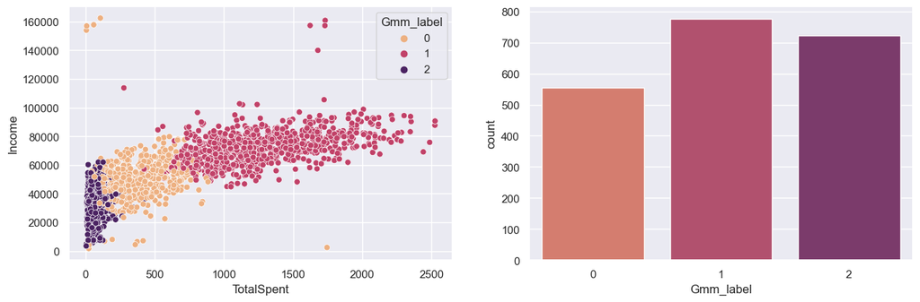

```python
gmm = GaussianMixture(n_components=3).fit(scaled_dataset2)
labels = gmm.predict(scaled_dataset2)
probs = gmm.predict_proba(scaled_dataset2)
cluster_dataset['Gmm_label'] = labels
#plot
plt.figure(figsize=(15,10))
ax = plt.subplot(gs[0, 0]) # row 0, col 0
sns.scatterplot(data=cluster_dataset, x = 'TotalSpent', y='Income', hue = 'Gmm_label',  palette='flare')
ax = plt.subplot(gs[0, 1]) # row 0, col 0
sns.countplot(x = cluster_dataset['Gmm_label'], palette='flare')
```

## 7) Choosing the best model

- We will choose the GMM model as it generated relatively equal clusters

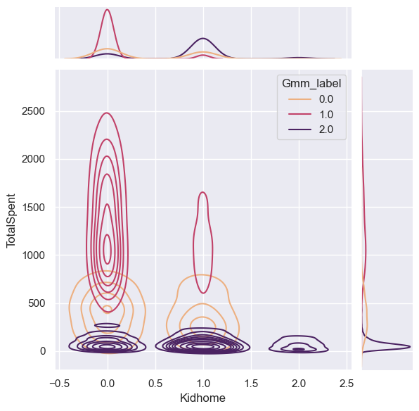

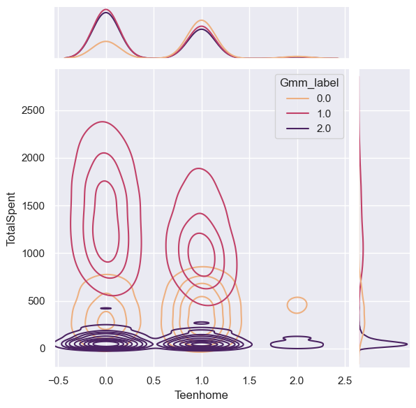

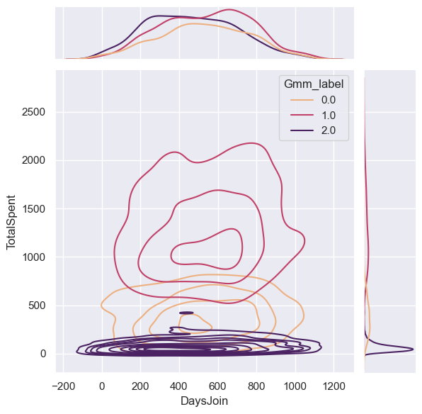

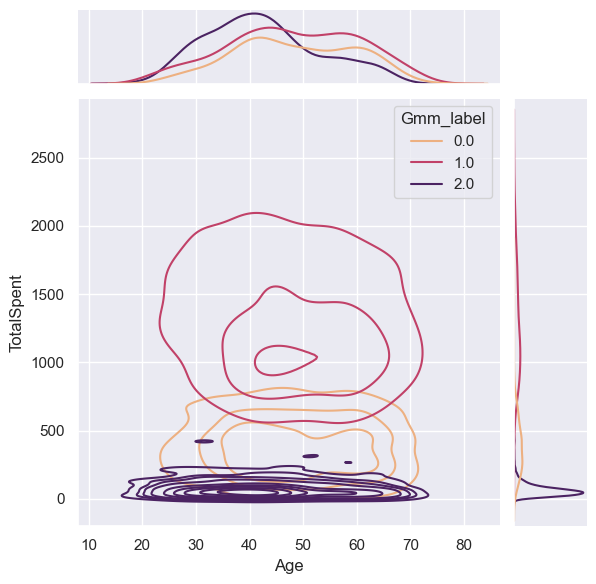

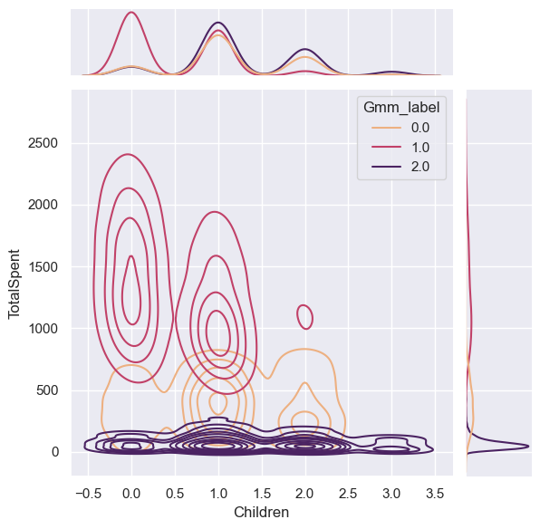

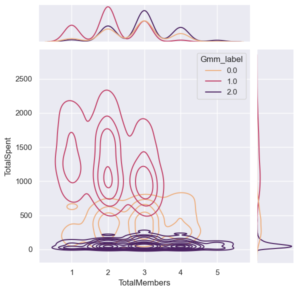

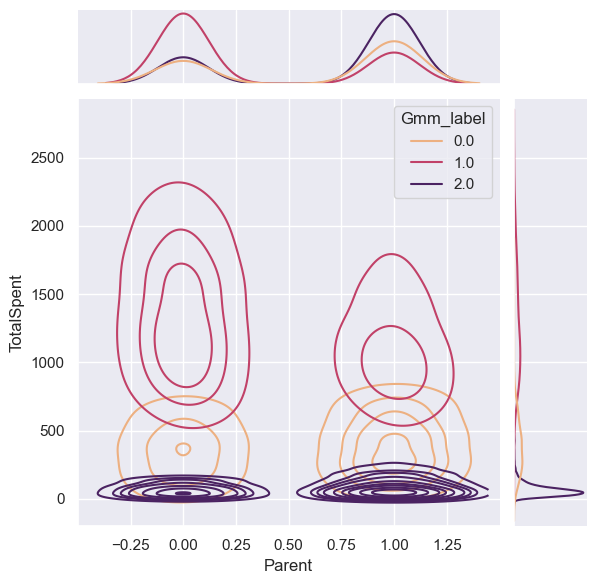

```python
Personal_infomation = [ "Kidhome","Teenhome","DaysJoin", "Age", "Children", "TotalMembers", "Parent"]

for feature in Personal_infomation:
    plt.figure(figsize=(10,10))
    sns.jointplot(x=clean_dataset[feature], y=dataset["TotalSpent"], hue =cluster_dataset["Gmm_label"], kind="kde", palette='flare')
    plt.show()
```

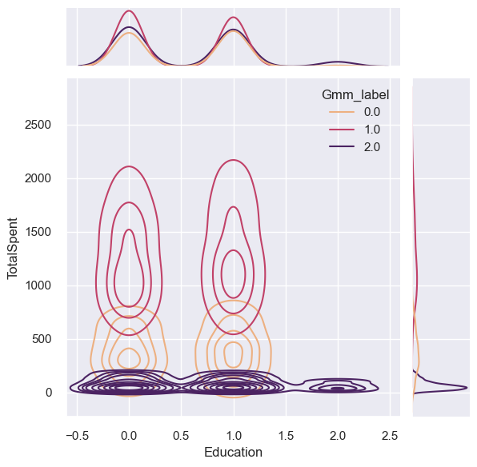

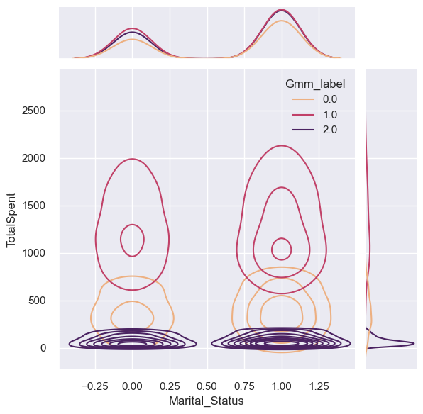

```python
sns.jointplot(x=pre_dataset['Education'], y=dataset["TotalSpent"], hue =cluster_dataset["Gmm_label"], kind="kde", palette='flare')
sns.jointplot(x=pre_dataset['Marital_Status'], y=dataset["TotalSpent"], hue =cluster_dataset["Gmm_label"], kind="kde", palette='flare')
```

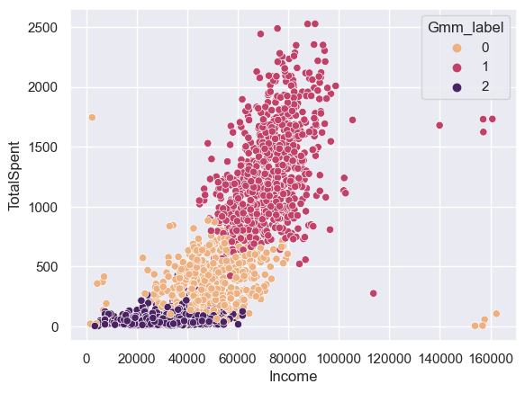

```python
sns.scatterplot(x=cluster_dataset['Income'], y=cluster_dataset["TotalSpent"], hue =cluster_dataset["Gmm_label"], palette='flare')
```

## Clusters Profile

Cluster 0:

1. Middle class payers
2. Have at most 2 children at home.
3. Family size does not exceed 4 members
4. Age between 25 and 70.
5. Amongst the cluster, customers who are parent spend a little more.
6. Customers are graduate and postgraduate only.
7. Moderate spendings, moderate to high incomes.

Cluster 1:

1. High class payers.
2. Have at most 1 child at home. Mostly a teen.
3. Family size does not exceed 3 members
4. Age between 25 and 75.
5. Amongst the cluster, customers who are not parent spend the most.
6. Customers are graduate and postgraduate only.
7. High spendings, moderate to high incomes.

Cluster 2:

1. Low class payers.
2. Have at most 3 children at home.
3. Family size reaches 5 members.
4. Age between 19 and 75.
5. Amongst the cluster, customers who are parent spend a little more.
6. The only cluster that include undergraduate customers.
7. low income, low spendings.

```python
recommendation_dataset = cluster_dataset.copy()
```

```python
encoded_label = {
    0: 'Middel_class',
    1: 'High_class',
    2: 'Low_class'
}

recommendation_dataset['Gmm_label'] = recommendation_dataset['Gmm_label'].apply(lambda cluster: encoded_label[cluster])
```

## Recommendations

```python
recommendation_dataset.columns
```

```
Index(['Year_Birth', 'Education', 'Marital_Status', 'Income', 'Kidhome',
       'Teenhome', 'Recency', 'Complain', 'MntDrinks', 'MntFruits',
       'MntMeatProducts', 'MntFishProducts', 'MntSweetProducts',
       'MntGoldProds', 'NumDealsPurchases', 'AcceptedCmp1', 'AcceptedCmp2',
       'AcceptedCmp3', 'AcceptedCmp4', 'AcceptedCmp5', 'Response',
       'NumWebPurchases', 'NumCatalogPurchases', 'NumStorePurchases',
       'NumWebVisitsMonth', 'DaysJoin', 'TotalSpent', 'Children', 'Age',
       'TotalMembers', 'Parent', 'TotalPurchase', 'TotalAcceptedCamps',
       'Kmeans_label', 'Kmediod_label', 'Gmm_label'],
      dtype='object')
```

```python
recommendation_dataset['Gmm_label'].value_counts()
```

```
High_class      777
Low_class       723
Middel_class    554
Name: Gmm_label, dtype: int64
```

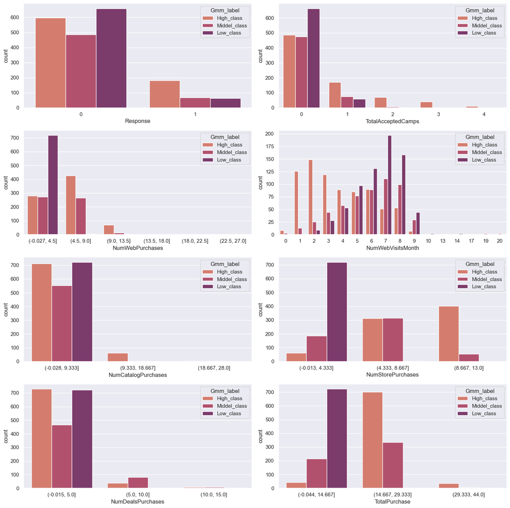

```python
plt.figure(figsize=(30,15))
gs1 = gridspec.GridSpec(4, 4)
ax = plt.subplot(gs1[0, 0]) # row 0, col 0
sns.countplot(data= recommendation_dataset, x='Response', hue = 'Gmm_label', palette = 'flare')
ax = plt.subplot(gs1[0, 1]) # row 0, col 0
sns.countplot(data= recommendation_dataset, x='TotalAcceptedCamps', hue = 'Gmm_label', palette = 'flare')
ax = plt.subplot(gs1[1, 0]) # row 0, col 0
sns.countplot(data= recommendation_dataset, x=pd.cut(recommendation_dataset['NumWebPurchases'],bins=6), hue = 'Gmm_label', palette = 'flare')
ax = plt.subplot(gs1[1, 1]) # row 0, col 0
sns.countplot(data= recommendation_dataset, x='NumWebVisitsMonth', hue = 'Gmm_label', palette = 'flare')
ax = plt.subplot(gs1[2, 0]) # row 0, col 0
sns.countplot(data= recommendation_dataset, x=pd.cut(recommendation_dataset['NumCatalogPurchases'],bins=3), hue = 'Gmm_label', palette = 'flare')
ax = plt.subplot(gs1[2, 1]) # row 0, col 0
sns.countplot(data= recommendation_dataset, x=pd.cut(recommendation_dataset['NumStorePurchases'],bins=3), hue = 'Gmm_label', palette = 'flare')
ax = plt.subplot(gs1[3, 1]) # row 0, col 0
sns.countplot(data= recommendation_dataset, x=pd.cut(recommendation_dataset['TotalPurchase'],bins=3), hue = 'Gmm_label', palette = 'flare')
ax = plt.subplot(gs1[3, 0]) # row 0, col 0
sns.countplot(data= recommendation_dataset, x=pd.cut(recommendation_dataset['NumDealsPurchases'],bins=3), hue = 'Gmm_label', palette = 'flare')

plt.tight_layout()
```

- Company's market campaigns are not successful amongst all clusters, even for the last campaign (Response). Company Needs to revisit their marketing strategy.
- Low class customers visit the website the most last month, but make the least website purchase. Company Needs to investigate their online market and make online promotions.
- Deals are not attracting customers that much, espcially low class customers. Company needs to put more deals because low class cluster is the second biggest cluster.

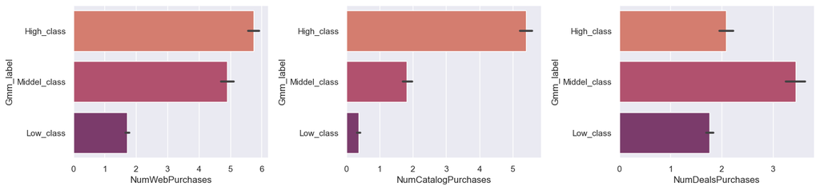

```python
features = recommendation_dataset[['NumWebPurchases', 'NumCatalogPurchases', 'NumDealsPurchases']]

plt.figure(figsize=(15,10))

i=1
nrows = int(features.shape[1]+1/3)
for feature in features.columns:
       plt.subplot(nrows, 3, i)
       # Plot the feature
       sns.barplot(data = recommendation_dataset, x = feature, y = 'Gmm_label', palette='flare')
       color=np.random.rand(3,)
       i+=1

plt.tight_layout()
plt.show()
```

- Low class likes to purchase through deals and website.
- Middle class likes to purchase through deals the most among the clusters, and website.
- High class likes to purchase through catalog the most among the clusters and website.

```python
recommendation_dataset[['NumWebPurchases', 'NumCatalogPurchases', 'NumDealsPurchases', 'Gmm_label']].groupby(by='Gmm_label').sum()
```

| Gmm_label | NumWebPurchases | NumCatalogPurchases | NumDealsPurchases |
| --- | --- | --- | --- |
| High_class | 4459 | 4190 | 1623 |
| Low_class | 1246 | 269 | 1277 |
| Middel_class | 2720 | 1009 | 1907 |